# Praktikum 6 Anreg

# Library

```r
library(readr)      # untuk membaca data
library(GGally)     # untuk menghasilkan matriks hubungan antarpeubah
library(corrplot)   # untuk menghasilkan matriks korelasi
library(dplyr)      # untuk manipulasi data
library(car)        # untuk memeriksa multikolinearitas
library(stargazer)  # untuk menampilkan hasil perbandingan regresi
library(lmtest)     # untuk uji kehomogenan ragam sisaan dan saling bebas
library(olsrr)      # untuk pemeriksaan amatan tidak biasa
```

# Data

```r
raw <- read_csv("financials.csv")
```

```r
# Seleksi dan bersihkan data
dt <- raw %>%
  transmute(
    Price = Price,
    EPS   = `Earnings/Share`,
    DY    = `Dividend Yield`,
    PS    = `Price/Sales`,
    PB    = `Price/Book`,
    Low52 = `52 Week Low`
  ) %>%
  filter(
    !is.na(Price), !is.na(EPS), !is.na(DY),
    !is.na(PS), !is.na(PB), !is.na(Low52),
    EPS > 0, Price > 0, PS > 0, PB > 0, Low52 > 0
  )

dt
```

```
## # A tibble: 448 × 6
##    Price   EPS    DY    PS    PB Low52
##    <dbl> <dbl> <dbl> <dbl> <dbl> <dbl>
##  1 223.   7.92 2.33   4.39 11.3  260.
##  2  60.2  1.7  1.15   3.58  6.35  68.4
##  3  56.3  0.26 1.91   3.74  3.19  64.6
##  4 108.   3.29 2.50   6.29 26.1  126.
##  5 151.   5.44 1.71   2.60 10.6  163.
##  6  65.8  1.28 0.432 10.6   5.16  74.9
##  7 145.   7.43 0.351  1.80  3.55 225.
##  8 185.   3.39 0     13.1  11.1  204.
##  9 110.   6.19 0.218  1.13  2.51 170.
## 10  11.2  0.03 0      2.11 21.5   15.6
## # ℹ 438 more rows
```

```r
str(dt)
```

```
## tibble [448 × 6] (S3: tbl_df/tbl/data.frame)
##  $ Price: num [1:448] 222.9 60.2 56.3 108.5 150.5 ...
##  $ EPS  : num [1:448] 7.92 1.7 0.26 3.29 5.44 1.28 7.43 3.39 6.19 0.03 ...
##  $ DY   : num [1:448] 2.33 1.15 1.91 2.5 1.71 ...
##  $ PS   : num [1:448] 4.39 3.58 3.74 6.29 2.6 ...
##  $ PB   : num [1:448] 11.34 6.35 3.19 26.14 10.62 ...
##  $ Low52: num [1:448] 259.8 68.4 64.6 125.9 162.6 ...
```

```r
summary(dt)
```

```
##      Price              EPS               DY                PS
##  Min.   :  10.43   Min.   : 0.010   Min.   : 0.0000   Min.   : 0.1532
##  1st Qu.:  50.20   1st Qu.: 1.895   1st Qu.: 0.8213   1st Qu.: 1.6510
##  Median :  76.81   Median : 3.165   Median : 1.8263   Median : 2.9157
##  Mean   : 109.66   Mean   : 4.578   Mean   : 1.9315   Mean   : 4.0034
##  3rd Qu.: 127.55   3rd Qu.: 5.463   3rd Qu.: 2.8151   3rd Qu.: 4.9152
##  Max.   :1806.06   Max.   :44.090   Max.   :12.6612   Max.   :20.0943
##        PB               Low52
##  Min.   :   0.660   Min.   :  13.48
##  1st Qu.:   2.100   1st Qu.:  59.83
##  Median :   3.595   Median :  89.77
##  Mean   :  15.259   Mean   : 129.15
##  3rd Qu.:   6.580   3rd Qu.: 148.54
##  Max.   :1403.380   Max.   :2067.99
```

Data yang digunakan adalah data keuangan perusahaan-perusahaan dalam indeks S&P 500 dengan 1 peubah respon yaitu Harga Saham (Price) dan 5 peubah penjelas. Peubah tersebut adalah Laba per Saham (EPS, *Earnings/Share*), Imbal Hasil Dividen (DY, *Dividend Yield*), Rasio Harga terhadap Penjualan (PS, *Price/Sales*), Rasio Harga terhadap Nilai Buku (PB, *Price/Book*), dan Harga Terendah 52 Minggu (Low52, *52 Week Low*).

# Eksplorasi Data

## Peubah Respon

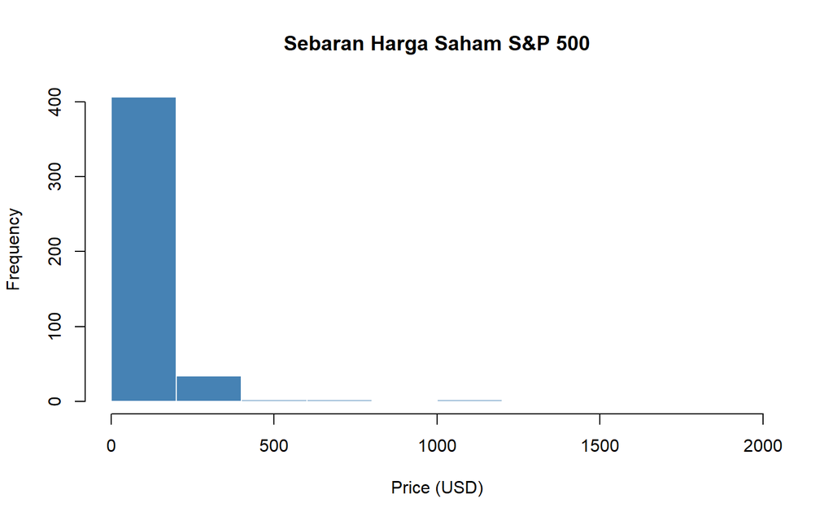

```r
hist(dt$Price,
     main = "Sebaran Harga Saham S&P 500",
     xlab = "Price (USD)", col = "steelblue", border = "white")
```

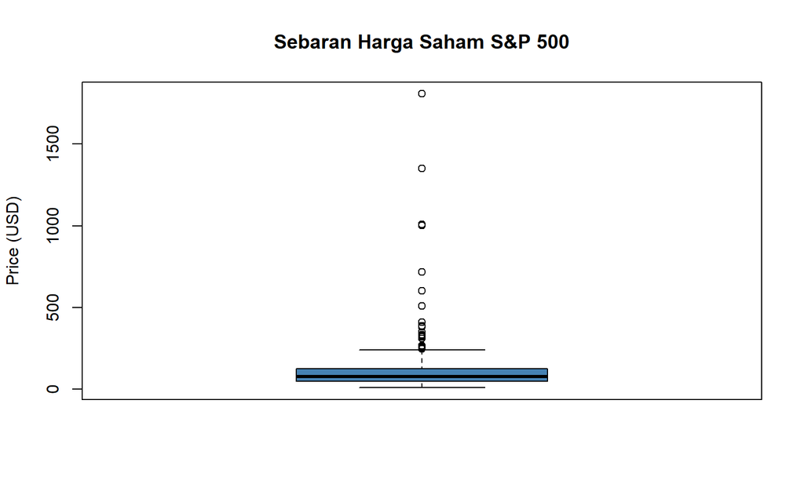

```r
boxplot(dt$Price,
        main = "Sebaran Harga Saham S&P 500",
        ylab = "Price (USD)", col = "steelblue")
```

## Peubah Penjelas vs Peubah Respon

### EPS (Earnings/Share)

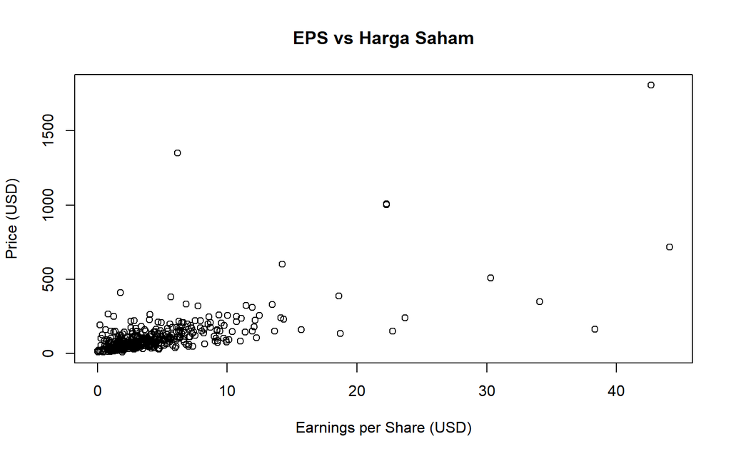

```r
plot(dt$EPS, dt$Price,
     xlab = "Earnings per Share (USD)",
     ylab = "Price (USD)",
     main = "EPS vs Harga Saham")
```

Hubungan antara peubah EPS dan Price cenderung positif namun tidak sepenuhnya linear, ada beberapa amatan dengan nilai EPS tinggi yang menyimpang dari pola umum.

### DY (Dividend Yield)

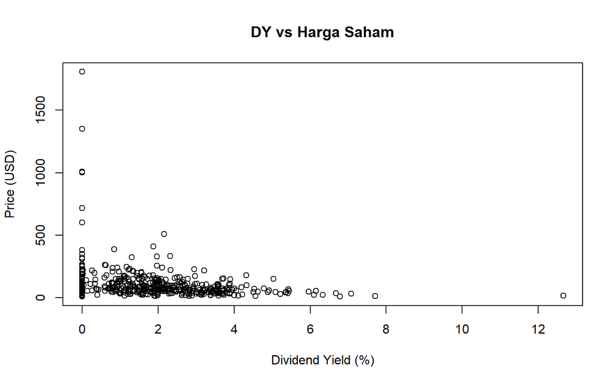

```r
plot(dt$DY, dt$Price,
     xlab = "Dividend Yield (%)",
     ylab = "Price (USD)",
     main = "DY vs Harga Saham")
```

Hubungan antara peubah DY dan Price tidak jelas arahnya, ada amatan dengan nilai DY 0 yang tersebar pada berbagai level harga.

### PS (Price/Sales)

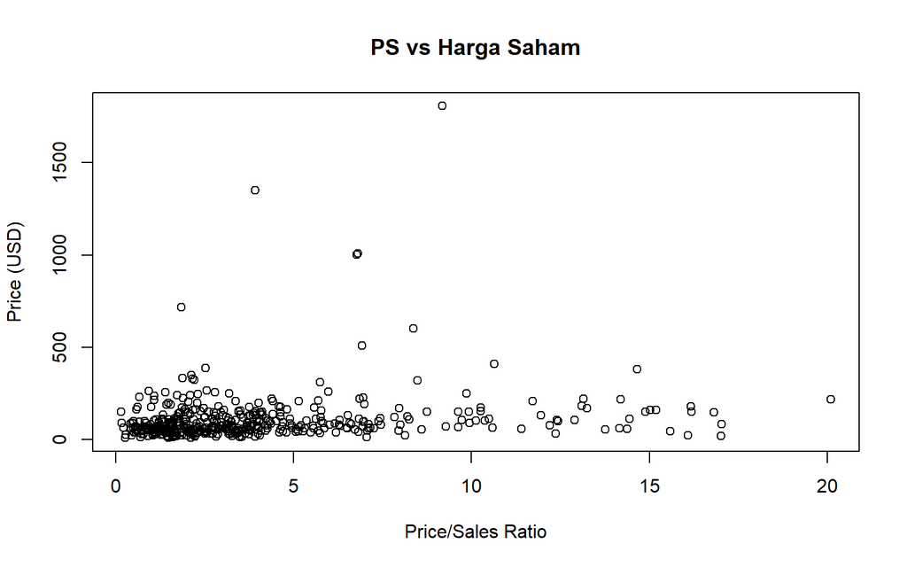

```r
plot(dt$PS, dt$Price,
     xlab = "Price/Sales Ratio",
     ylab = "Price (USD)",
     main = "PS vs Harga Saham")
```

Hubungan positif tampak antara peubah PS dan Price karena PS sendiri mengandung komponen harga. Ada beberapa amatan dengan nilai yang jauh dari amatan lainnya.

### PB (Price/Book)

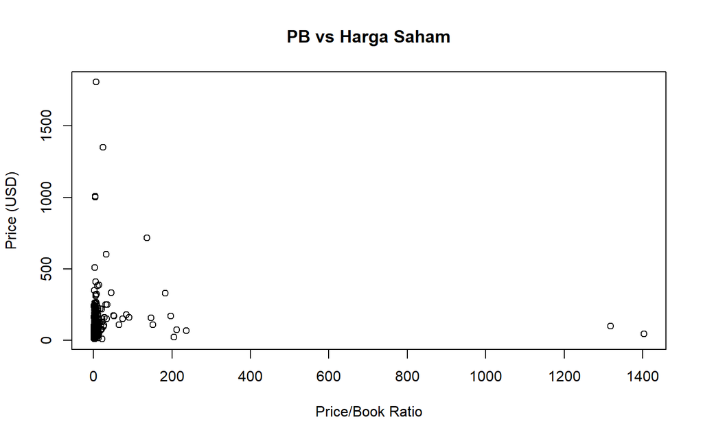

```r
plot(dt$PB, dt$Price,
     xlab = "Price/Book Ratio",
     ylab = "Price (USD)",
     main = "PB vs Harga Saham")
```

Hubungan antara peubah PB dan Price cenderung lemah dan tersebar, ada amatan dengan nilai PB sangat tinggi (perusahaan dengan nilai buku rendah).

### Low52 (52 Week Low)

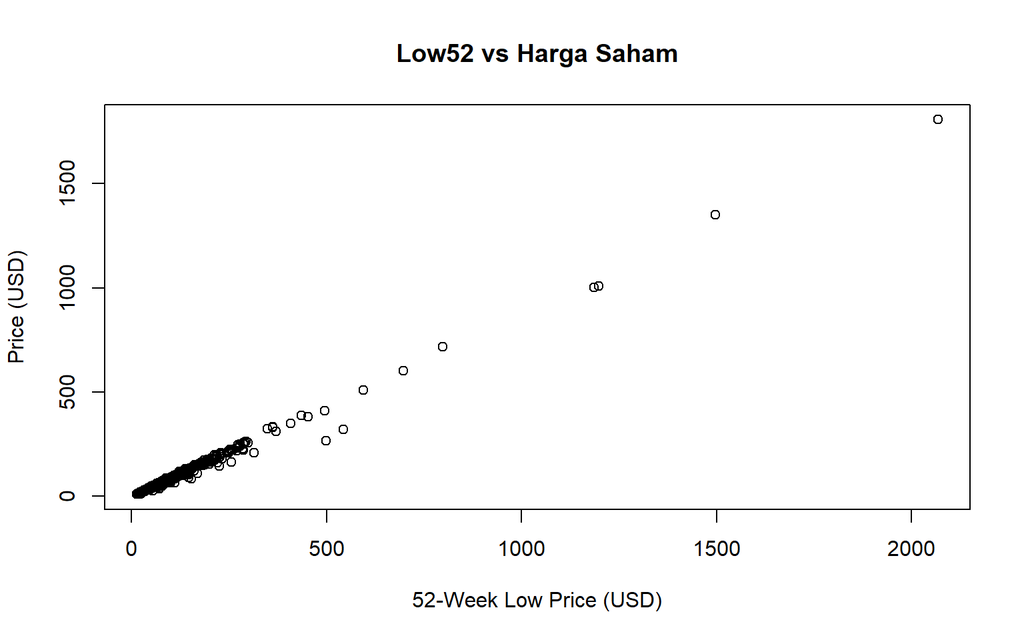

```r
plot(dt$Low52, dt$Price,
     xlab = "52-Week Low Price (USD)",
     ylab = "Price (USD)",
     main = "Low52 vs Harga Saham")
```

Hubungan linearitas sangat kuat antara peubah Low52 dan Price. Hal ini sangat wajar karena harga terendah 52 minggu adalah harga historis saham yang sama, sehingga keduanya bergerak bersama.

## Korelasi

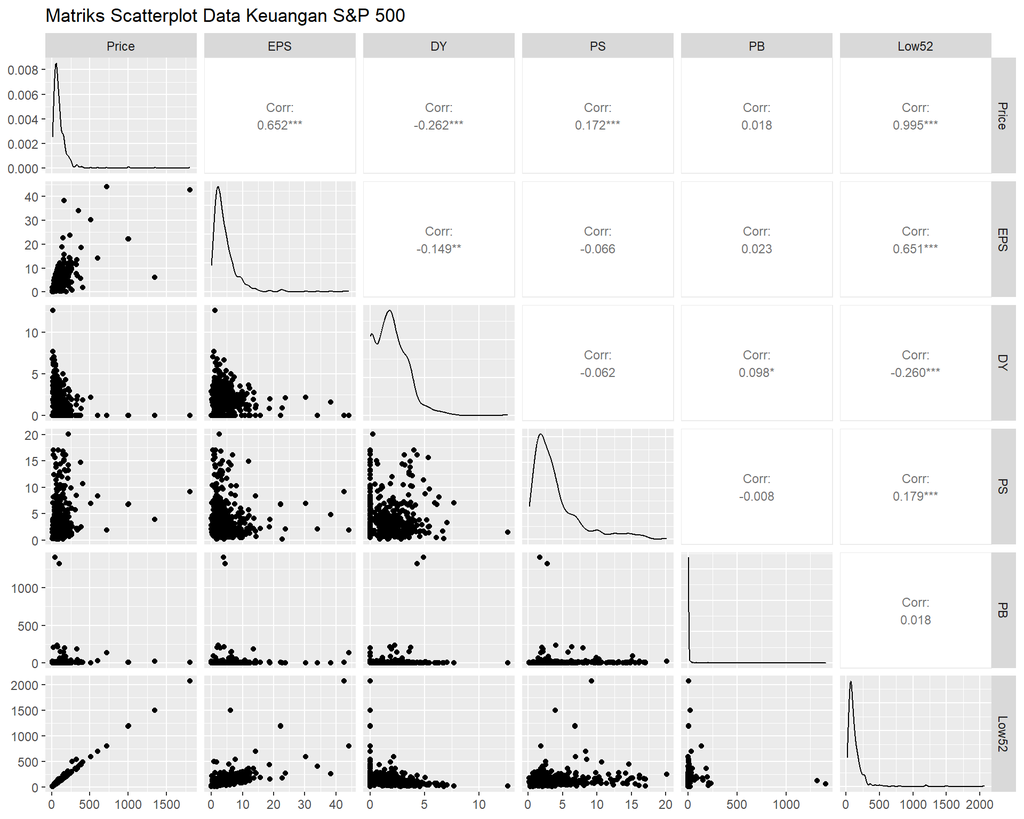

```r
ggpairs(dt,
        upper = list(continuous = wrap('cor', size = 3)),
        title = "Matriks Scatterplot Data Keuangan S&P 500")
```

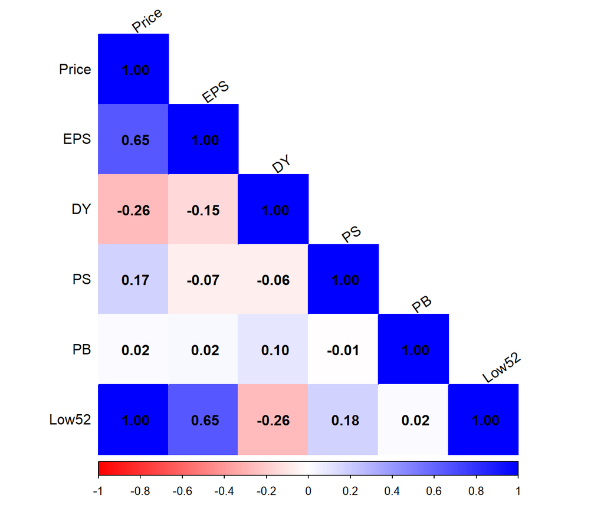

```r
cor_matrix <- cor(dt, use = "complete.obs")

corrplot(cor_matrix, method = "color", type = "lower",
         col = colorRampPalette(c("red", "white", "blue"))(200),
         addCoef.col = "black", tl.col = "black", tl.srt = 35)
```

# Pemodelan

```r
model1 <- lm(formula = Price ~ ., data = dt)
summary(model1)
```

```
##
## Call:
## lm(formula = Price ~ ., data = dt)
##
## Residuals:
##      Min       1Q   Median       3Q      Max
## -161.066   -1.540    1.489    4.303   66.452
##
## Coefficients:
##               Estimate Std. Error t value Pr(>|t|)
## (Intercept) -0.2519041  1.5499924  -0.163    0.871
## EPS          0.1530665  0.1786813   0.857    0.392
## DY          -0.3007809  0.4423995  -0.680    0.497
## PS          -0.2351073  0.1961317  -1.199    0.231
## PB           0.0009916  0.0070671   0.140    0.888
## Low52        0.8573136  0.0057059 150.251   <2e-16 ***
## ---
## Signif. codes:  0 '***' 0.001 '**' 0.01 '*' 0.05 '.' 0.1 ' ' 1
##
## Residual standard error: 13.94 on 442 degrees of freedom
## Multiple R-squared:  0.9903, Adjusted R-squared:  0.9902
## F-statistic:  9020 on 5 and 442 DF,  p-value: < 2.2e-16
```

Persamaan yang terbentuk dari pemodelan awal adalah:

$$\hat{\text{Price}} = \hat{\beta}_0 +
\hat{\beta}_1\,\text{EPS} + \hat{\beta}_2\,\text{DY} +
\hat{\beta}_3\,\text{PS} + \hat{\beta}_4\,\text{PB} +
\hat{\beta}_5\,\text{Low52}$$

Pada ringkasan model ini dapat dilihat bahwa secara simultan minimal ada satu peubah penjelas yang berpengaruh signifikan terhadap Price. Namun demikian, beberapa koefisien mungkin tidak sesuai arah yang diharapkan atau tidak signifikan secara individual, mengindikasikan adanya permasalahan multikolinearitas dalam model. Selanjutnya diperlukan pemeriksaan multikolinearitas dilanjutkan dengan diagnosis sisaan.

# Pemeriksaan Multikolinearitas

## Perubahan Peubah

```r
mod1 <- lm(Price ~ ., dt[1:2])
mod2 <- lm(Price ~ ., dt[1:3])
mod3 <- lm(Price ~ ., dt[1:4])
mod4 <- lm(Price ~ ., dt[1:5])
mod5 <- lm(Price ~ ., dt)

stargazer(mod1, mod2, mod3, mod4, mod5,
          type = "text", single.row = TRUE)
```

```
##
## ==================================================================================================================================================
##                                                                          Dependent variable:
##                     ------------------------------------------------------------------------------------------------------------------------------
##                                                                                 Price
##                               (1)                      (2)                      (3)                      (4)                       (5)
## --------------------------------------------------------------------------------------------------------------------------------------------------
## EPS                    18.291*** (1.007)        17.586*** (0.995)        18.028*** (0.961)        18.006*** (0.962)           0.153 (0.179)
## DY                                              -15.234*** (3.214)       -13.869*** (3.101)       -14.063*** (3.120)          -0.301 (0.442)
## PS                                                                        8.177*** (1.354)         8.176*** (1.355)           -0.235 (0.196)
## PB                                                                                                  0.031 (0.051)             0.001 (0.007)
## Low52                                                                                                                        0.857*** (0.006)
## Constant               25.922*** (6.837)        58.572*** (9.594)         21.176* (11.117)         21.180* (11.125)           -0.252 (1.550)
## --------------------------------------------------------------------------------------------------------------------------------------------------
## Observations                  448                      448                      448                      448                       448
## R2                           0.425                    0.453                    0.494                    0.495                     0.990
## Adjusted R2                  0.424                    0.450                    0.491                    0.490                     0.990
## Residual Std. Error    106.807 (df = 446)       104.326 (df = 445)       100.401 (df = 444)       100.472 (df = 443)        13.939 (df = 442)
## F Statistic         329.629*** (df = 1; 446) 183.979*** (df = 2; 445) 144.586*** (df = 3; 444) 108.379*** (df = 4; 443) 9,020.064*** (df = 5; 442)
## ==================================================================================================================================================
## Note:                                                                                                                  *p<0.1; **p<0.05; ***p<0.01
```

Terdapat perubahan tanda dan besar dugaan parameter ketika peubah baru ditambahkan. Hasil ini mengindikasikan adanya permasalahan multikolinearitas dalam model.

## Perubahan Banyak Data

```r
n_half  <- floor(nrow(dt) * 0.7)
mod5_1  <- lm(Price ~ ., dt[1:n_half, ])

stargazer(summary(mod5)$coefficients, summary(mod5_1)$coefficients,
          type = "text", font.size = "small")
```

```
##
## ===================================================
##             Estimate Std. Error t value Pr(> | t| )
## ---------------------------------------------------
## (Intercept)  -0.252    1.550    -0.163     0.871
## EPS          0.153     0.179     0.857     0.392
## DY           -0.301    0.442    -0.680     0.497
## PS           -0.235    0.196    -1.199     0.231
## PB           0.001     0.007     0.140     0.888
## Low52        0.857     0.006    150.251      0
## ---------------------------------------------------
##
## ===================================================
##             Estimate Std. Error t value Pr(> | t| )
## ---------------------------------------------------
## (Intercept)  -0.213    1.809    -0.118     0.907
## EPS          0.010     0.181     0.054     0.957
## DY           -0.099    0.506    -0.196     0.845
## PS           -0.282    0.225    -1.249     0.213
## PB           0.003     0.009     0.299     0.765
## Low52        0.861     0.006    133.437      0
## ---------------------------------------------------
```

Terdapat dugaan parameter yang mengalami perubahan besar ketika jumlah amatan berbeda, mengindikasikan model bermasalah akibat multikolinearitas.

## Akar Ciri

```r
x_mat <- as.matrix(dt[, -1])   # semua peubah penjelas
r     <- cor(x_mat)
(ev   <- eigen(r)$values)
```

```
## [1] 1.7752230 1.0813073 1.0160255 0.8288587 0.2985855
```

```r
# Uji simultan
if ((max(ev) / min(ev)) <= 100) {
  cat("Tidak ada multikolinearitas\n")
} else if ((max(ev) / min(ev)) > 100 & (max(ev) / min(ev)) <= 1000) {
  cat("Ada multikolinearitas yang lemah\n")
} else {
  cat("Ada multikolinearitas yang kuat\n")
}
```

```
## Tidak ada multikolinearitas
```

```r
# Uji parsial
if (all((max(ev) / ev) <= 1000)) {
  cat("Tidak ada multikolinearitas\n")
} else {
  cat("Ada multikolinearitas pada peubah penjelas ke:", which((max(ev) / ev) > 1000), "\n")
}
```

```
## Tidak ada multikolinearitas
```

## Nilai VIF

```r
vif(model1)
```

```
##      EPS       DY       PS       PB    Low52
## 1.847088 1.085597 1.099296 1.011862 1.984102
```

# Pemodelan Penyisihan Peubah

```r
model2 <- lm(Price ~ EPS + DY + PS + PB, data = dt)
summary(model2)
```

```
##
## Call:
## lm(formula = Price ~ EPS + DY + PS + PB, data = dt)
##
## Residuals:
##     Min      1Q  Median      3Q     Max
## -563.85  -30.70   -4.75   17.35 1185.54
##
## Coefficients:
##              Estimate Std. Error t value Pr(>|t|)
## (Intercept)  21.17962   11.12526   1.904   0.0576 .
## EPS          18.00627    0.96192  18.719  < 2e-16 ***
## DY          -14.06287    3.11981  -4.508 8.40e-06 ***
## PS            8.17629    1.35494   6.034 3.37e-09 ***
## PB            0.03106    0.05092   0.610   0.5422
## ---
## Signif. codes:  0 '***' 0.001 '**' 0.01 '*' 0.05 '.' 0.1 ' ' 1
##
## Residual standard error: 100.5 on 443 degrees of freedom
## Multiple R-squared:  0.4946, Adjusted R-squared:   0.49
## F-statistic: 108.4 on 4 and 443 DF,  p-value: < 2.2e-16
```

Persamaan yang terbentuk adalah:

$$\hat{\text{Price}} = \hat{\beta}_0 +
\hat{\beta}_1\,\text{EPS} + \hat{\beta}_2\,\text{DY} +
\hat{\beta}_3\,\text{PS} + \hat{\beta}_4\,\text{PB}$$

Pada ringkasan model ini dapat dilihat bahwa secara simultan minimal ada satu peubah penjelas yang berpengaruh signifikan terhadap Price.

## Nilai VIF

```r
vif(model2)
```

```
##      EPS       DY       PS       PB
## 1.030273 1.039063 1.009736 1.011051
```

Model hasil reduksi peubah menunjukkan nilai VIF yang lebih terkendali. Namun masih perlu dilakukan pengujian asumsi sisaan dan pemeriksaan amatan tidak biasa untuk memastikan validitas model.

# Pengujian Asumsi

## Eksplorasi Grafik

### Plot Sisaan vs Y Duga

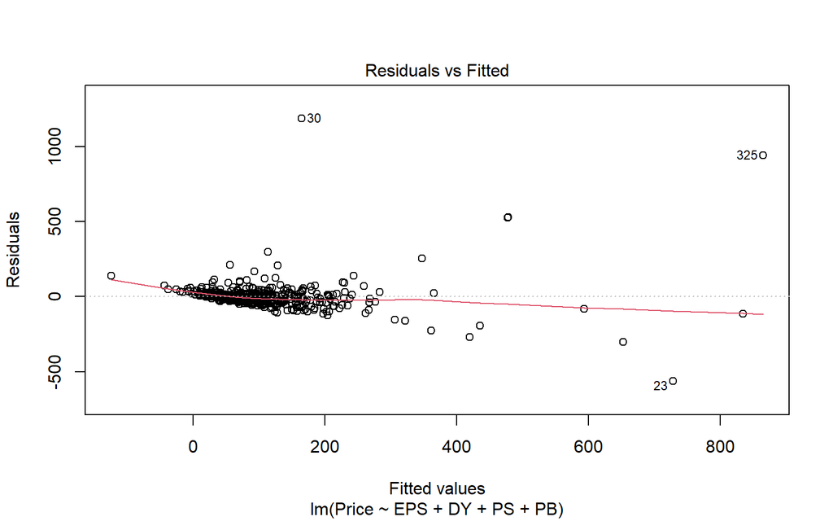

```r
plot(model2, 1)
```

Perhatikan pola yang terbentuk pada plot sisaan vs nilai dugaan:  
1. Apakah sisaan tersebar di sekitar 0? → Nilai harapan sisaan  
2. Apakah lebar pita relatif sama di setiap nilai dugaan? → Keragaman sisaan  
3. Apakah ada pola tertentu? → Linearitas model

### Plot Sisaan vs Urutan

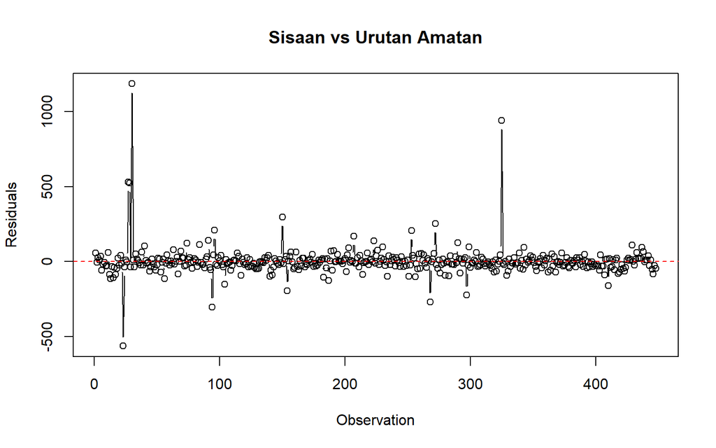

```r
plot(x = 1:nrow(dt),
     y = model2$residuals,
     type = 'b',
     ylab = "Residuals",
     xlab = "Observation",
     main = "Sisaan vs Urutan Amatan")
abline(h = 0, col = "red", lty = 2)
```

Periksa apakah ada pola bergelombang (tanda autokorelasi) atau tebaran acak (sisaan saling bebas).

### QQ Plot

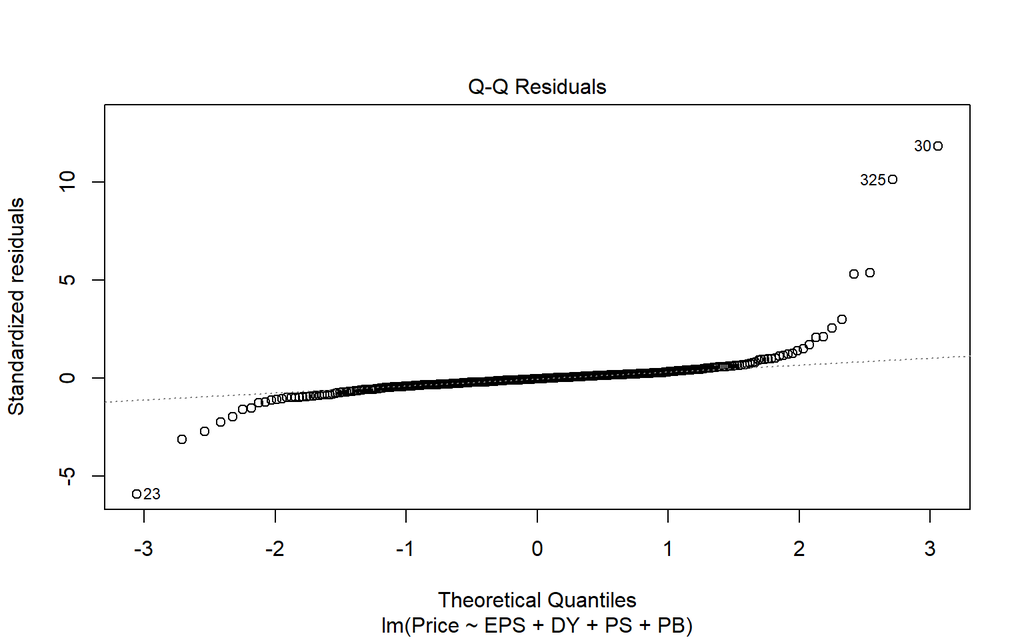

```r
plot(model2, 2)
```

Apakah amatan mengikuti garis diagonal? Jika ya, sisaan menyebar normal.

## Uji Formal

### Nilai Harapan Sisaan Sama dengan Nol

```r
t.test(model2$residuals, mu = 0, conf.level = 0.95)
```

```
##
##  One Sample t-test
##
## data:  model2$residuals
## t = -3.4825e-18, df = 447, p-value = 1
## alternative hypothesis: true mean is not equal to 0
## 95 percent confidence interval:
##  -9.287124  9.287124
## sample estimates:
##     mean of x
## -1.645664e-17
```

Nilai p pada uji t dibandingkan dengan alpha 5%. Jika p > 0.05 maka asumsi nilai harapan sisaan sama dengan nol terpenuhi.

### Ragam Sisaan Homogen (Breusch-Pagan)

```r
bptest(model2)
```

```
##
##  studentized Breusch-Pagan test
##
## data:  model2
## BP = 57.729, df = 4, p-value = 8.699e-12
```

Nilai p pada uji Breusch-Pagan dibandingkan dengan alpha 5%. Jika p > 0.05 maka asumsi ragam sisaan homogen (homoskedastisitas) terpenuhi.

### Sisaan Saling Bebas (Durbin-Watson)

```r
dwtest(model2)
```

```
##
##  Durbin-Watson test
##
## data:  model2
## DW = 1.8657, p-value = 0.07652
## alternative hypothesis: true autocorrelation is greater than 0
```

Nilai p pada uji Durbin-Watson dibandingkan dengan alpha 5%. Jika p > 0.05 maka asumsi sisaan saling bebas terpenuhi.

### Normalitas Sisaan (Shapiro-Wilk)

```r
shapiro.test(model2$residuals)
```

```
##
##  Shapiro-Wilk normality test
##
## data:  model2$residuals
## W = 0.51343, p-value < 2.2e-16
```

Nilai p pada uji Shapiro-Wilk dibandingkan dengan alpha 5%. Jika p > 0.05 maka asumsi normalitas sisaan terpenuhi.

Periksa semua hasil uji di atas secara bersama. Jika ada asumsi yang tidak terpenuhi, perlu dilakukan penanganan lebih lanjut (transformasi, pemilihan model alternatif). Jika semua asumsi terpenuhi namun model masih kurang baik, kemungkinan disebabkan oleh keberadaan amatan yang tidak biasa seperti pencilan, leverage, atau amatan berpengaruh.

# Pemeriksaan Amatan Tidak Biasa

```r
# Fungsi bawaan R
ri_stud    <- rstudent(model2)
ri_stan    <- rstandard(model2)
hii_fungsi <- hatvalues(model2)

# Manual
X           <- model.matrix(model2)
X_inv_xt    <- X %*% solve(t(X) %*% X) %*% t(X)
hii_manual  <- diag(X_inv_xt)
anova_model <- anova(model2)
s           <- sqrt(anova_model["Residuals", "Mean Sq"])
ei          <- model2$residuals
ri_manual   <- ei / (s * sqrt(1 - hii_manual))

nilai <- data.frame(ri_stud, ri_stan, ri_manual, hii_fungsi, hii_manual)
print(round(nilai, 4))
```

```
##     ri_stud ri_stan ri_manual hii_fungsi hii_manual
## 1    0.5545  0.5550    0.5550     0.0036     0.0036
## 2   -0.0482 -0.0482   -0.0482     0.0039     0.0039
## 3    0.2647  0.2650    0.2650     0.0040     0.0040
## 4    0.1091  0.1093    0.1093     0.0036     0.0036
## 5    0.3372  0.3375    0.3375     0.0027     0.0027
## 6   -0.5917 -0.5921   -0.5921     0.0127     0.0127
## 7   -0.1935 -0.1937   -0.1937     0.0059     0.0059
## 8   -0.0447 -0.0448   -0.0448     0.0199     0.0199
## 9   -0.2919 -0.2922   -0.2922     0.0067     0.0067
## 10  -0.2839 -0.2842   -0.2842     0.0096     0.0096
## 11   0.6036  0.6041    0.6041     0.0047     0.0047
## 12  -0.8798 -0.8800   -0.8800     0.0082     0.0082
## 13  -1.1460 -1.1455   -1.1455     0.0074     0.0074
## 14  -0.3475 -0.3478   -0.3478     0.0049     0.0049
```

[output cut: 434 more lines]

## Pencilan

```r
absri   <- abs(nilai[, 2])
pencilan <- which(absri > 2)
cat("Amatan yang terdeteksi sebagai pencilan:", pencilan, "\n")
```

```
## Amatan yang terdeteksi sebagai pencilan: 23 27 28 30 94 96 150 253 268 272 297 325
```

Amatan dengan nilai sisaan terstandarkan mutlak lebih dari 2 terdeteksi sebagai pencilan (*outlier*).

## Leverage

```r
n       <- nrow(dt)
p       <- length(model2$coefficients)
cutoff  <- 2 * p / n

titik_leverage <- which(hii_fungsi > cutoff)
cat("Amatan yang terdeteksi sebagai leverage:", titik_leverage, "\n")
```

```
## Amatan yang terdeteksi sebagai leverage: 23 27 28 44 56 67 91 94 104 140 152 154 174 183 197 214 223 226 238 244 265 268 283 302 318 325 329 332 340 342 355 356 421 423
```

```r
cat("Nilai cutoff leverage:", round(cutoff, 4), "\n")
```

```
## Nilai cutoff leverage: 0.0223
```

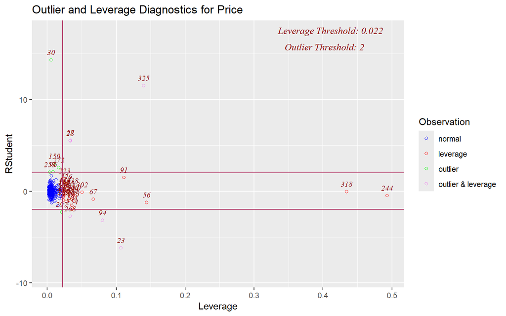

```r
ols_plot_resid_lev(model2)
```

Amatan tertentu terdeteksi sebagai titik leverage karena memiliki nilai hat ($h_{ii}$) melampaui nilai cutoff $2p/n$.

## Amatan Berpengaruh

### Jarak Cook

```r
di           <- cooks.distance(model2)
f_crit       <- qf(0.05, p, n - p, lower.tail = FALSE)
cook_result  <- data.frame(CookDistance = round(di, 6), Berpengaruh = di > f_crit)
print(cook_result)
```

```
##     CookDistance Berpengaruh
## 1       0.000223       FALSE
## 2       0.000002       FALSE
## 3       0.000056       FALSE
## 4       0.000009       FALSE
## 5       0.000061       FALSE
## 6       0.000902       FALSE
## 7       0.000045       FALSE
## 8       0.000008       FALSE
## 9       0.000116       FALSE
## 10      0.000157       FALSE
## 11      0.000342       FALSE
## 12      0.001282       FALSE
## 13      0.001951       FALSE
## 14      0.000120       FALSE
```

[output cut: 434 more lines]

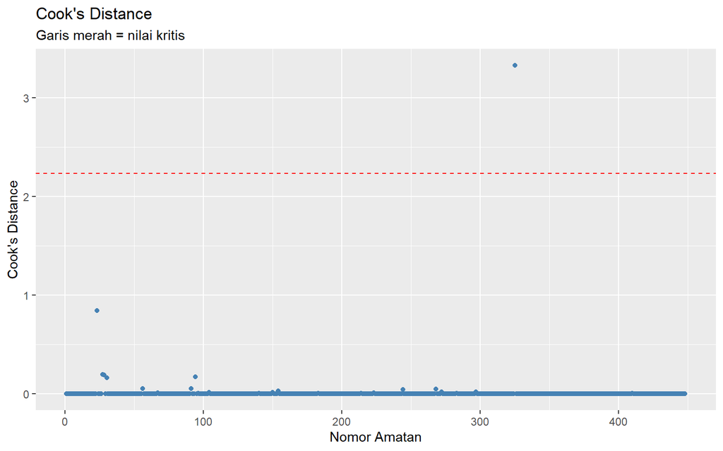

```r
df_cook <- data.frame(obs = seq_along(di), cooks = di)
library(ggplot2)
ggplot(df_cook, aes(x = obs, y = cooks)) +
  geom_point(color = "steelblue") +
  geom_hline(yintercept = f_crit, linetype = "dashed", color = "red") +
  labs(title  = "Cook's Distance",
       subtitle = "Garis merah = nilai kritis",
       x = "Nomor Amatan",
       y = "Cook's Distance")
```

Pemeriksaan amatan berpengaruh dengan jarak Cook menunjukkan apakah ada amatan yang melebihi ambang batas kritis.

### DFBETAS

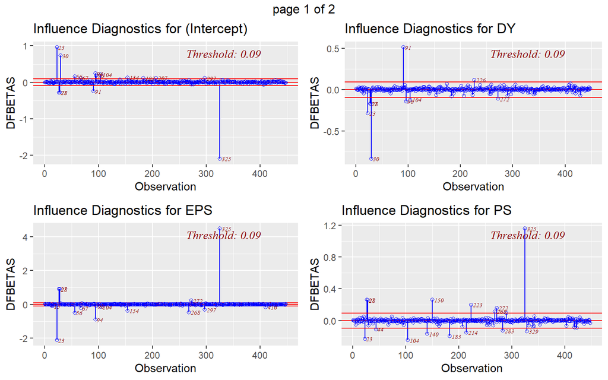

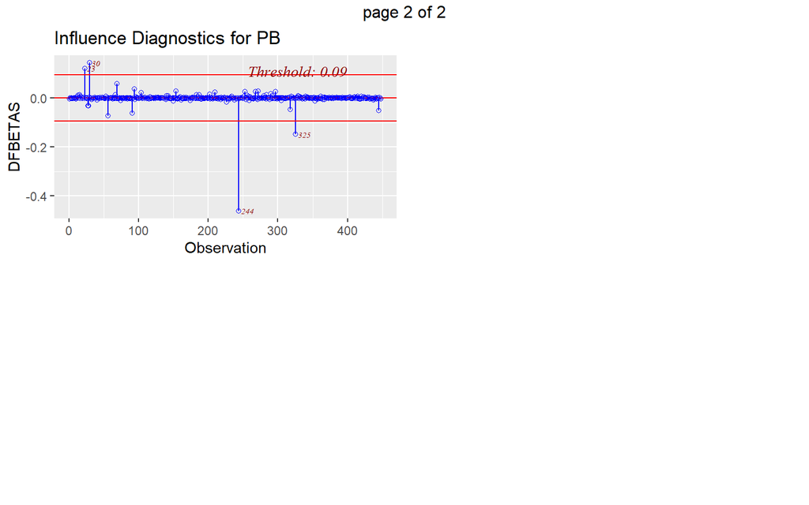

```r
ols_plot_dfbetas(model2)
```

Hasil DFBETAS menunjukkan pengaruh setiap observasi terhadap masing-masing koefisien regresi. DFBETAS mengukur seberapa besar koefisien regresi berubah jika suatu observasi dihapus dari model.

### DFFITS

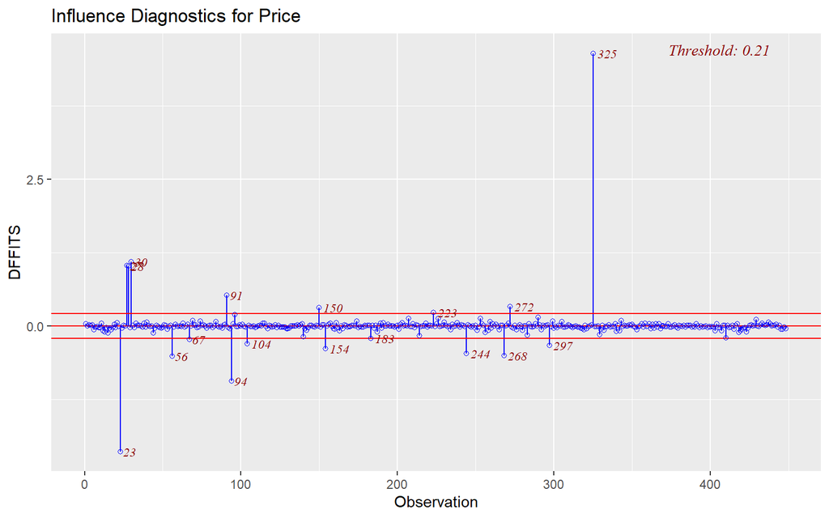

```r
ols_plot_dffits(model2)
```

```r
DFFITSi   <- dffits(model2)
cutoff_df <- 2 * sqrt(p / n)

amatan_berpengaruh <- which(abs(DFFITSi) > cutoff_df)
cat("Amatan berpengaruh berdasarkan DFFITS:", sort(unique(amatan_berpengaruh)), "\n")
```

```
## Amatan berpengaruh berdasarkan DFFITS: 23 27 28 30 56 67 91 94 104 150 154 183 223 244 268 272 297 325
```

Hasil DFFITS menunjukkan pengaruh observasi terhadap nilai prediksi $\hat{Y}$. DFFITS mengukur seberapa besar nilai prediksi $\hat{Y}_i$ berubah jika suatu observasi dihapus dari model.

# Pemodelan Penyisihan Amatan

```r
# Identifikasi semua amatan tidak biasa
amatan_unik <- sort(unique(c(pencilan, titik_leverage, amatan_berpengaruh)))
cat("Semua amatan tidak biasa:", amatan_unik, "\n")
```

```
## Semua amatan tidak biasa: 23 27 28 30 44 56 67 91 94 96 104 140 150 152 154 174 183 197 214 223 226 238 244 253 265 268 272 283 297 302 318 325 329 332 340 342 355 356 421 423
```

```r
# Buat model-model dengan penyisihan amatan berbeda
models_list <- list()

# Model tanpa penyisihan (baseline)
models_list[["Model Baseline"]] <- model2

# Penyisihan masing-masing amatan individu
for (i in seq_along(amatan_unik)) {
  idx  <- amatan_unik[i]
  nm   <- paste0("Tanpa Amatan ", idx)
  dt_i <- dt[-idx, ]
  models_list[[nm]] <- lm(Price ~ EPS + DY + PS + PB, data = dt_i)
}

# Penyisihan semua sekaligus
if (length(amatan_unik) > 0) {
  dt_all <- dt[-amatan_unik, ]
  models_list[["Tanpa Semua Amatan Tidak Biasa"]] <- lm(Price ~ EPS + DY + PS + PB, data = dt_all)
}
```

```r
get_metrics <- function(model) {
  adj_r2 <- summary(model)$adj.r.squared
  sse    <- sum(model$residuals^2)
  return(c(adj_r2, sse))
}

model_metrics <- data.frame(
  Model       = names(models_list),
  Adjusted_R2 = sapply(models_list, function(m) get_metrics(m)[1]),
  SSE         = sapply(models_list, function(m) get_metrics(m)[2]),
  row.names   = NULL
)

print(model_metrics)
```

```
##                             Model Adjusted_R2       SSE
## 1                  Model Baseline   0.4900272 4471949.4
## 2                 Tanpa Amatan 23   0.5304505 4116006.6
## 3                 Tanpa Amatan 27   0.4751881 4181583.8
## 4                 Tanpa Amatan 28   0.4750975 4188081.9
## 5                 Tanpa Amatan 30   0.5775736 3058172.4
## 6                 Tanpa Amatan 44   0.4904094 4467730.8
## 7                 Tanpa Amatan 56   0.4695273 4456265.0
## 8                 Tanpa Amatan 67   0.4814868 4464462.8
## 9                 Tanpa Amatan 91   0.4920303 4449886.2
## 10                Tanpa Amatan 94   0.4981976 4371747.6
## 11                Tanpa Amatan 96   0.4936563 4427742.3
## 12               Tanpa Amatan 104   0.4926809 4447640.8
## 13               Tanpa Amatan 140   0.4907680 4461695.8
## 14               Tanpa Amatan 150   0.4949691 4383283.4
```

[output cut: 28 more lines]

Berdasarkan hasil perbandingan tersebut, model terbaik dipilih berdasarkan nilai Adjusted R-Squared terbesar dan SSE terkecil. Model terpilih menunjukkan seberapa besar dampak amatan tidak biasa terhadap kualitas pemodelan harga saham S&P 500.

```r
# Tampilkan perbandingan model baseline vs model terbaik
best_idx   <- which.max(model_metrics$Adjusted_R2)
best_model <- models_list[[best_idx]]

stargazer(model2, best_model,
          type      = "text",
          font.size = "small",
          report    = "vc*p",
          column.labels = c("Baseline", "Model Terbaik"))
```

```
##
## =====================================================================
##                                    Dependent variable:
##                     -------------------------------------------------
##                                           Price
##                             Baseline              Model Terbaik
##                               (1)                      (2)
## ---------------------------------------------------------------------
## EPS                        18.006***                14.442***
##                            p = 0.000                p = 0.000
##
## DY                         -14.063***               -9.415***
##                           p = 0.00001               p = 0.000
##
## PS                          8.176***                 6.692***
##                            p = 0.000                p = 0.000
##
## PB                           0.031                   0.191**
##                            p = 0.543                p = 0.011
##
## Constant                    21.180*                 26.165***
##                            p = 0.058               p = 0.00001
##
## ---------------------------------------------------------------------
## Observations                  448                      408
## R2                           0.495                    0.613
## Adjusted R2                  0.490                    0.609
## Residual Std. Error    100.472 (df = 443)       37.905 (df = 403)
## F Statistic         108.379*** (df = 4; 443) 159.349*** (df = 4; 403)
## =====================================================================
## Note:                                     *p<0.1; **p<0.05; ***p<0.01
```